# STAT 440 Statistical Data Management - Spring 2022

### Employing Visual Hierarchy

Employing Visual Hierarchy is partly removing clutter and partly using preattentive attributes such as text size, text emphasis, color, and lines to draw the audience’s eyes where you want them to go.

The following graphic comes from Chapter 4 of Knaflic’s [Storytelling with Data](https://www.storytellingwithdata.com/) book. Notice how your eyes navigate the image. Write down where your eyes go first, second, and third.

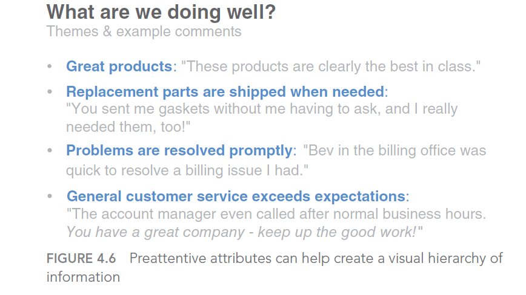

This kind of visual hierarchy can be employed in data viz as well by manipulating the Macro and Micro elements mentioned above. See Knaflic’s graphics below for a transformation of data visualization beginning with a basic plot and becoming a plot that is informative and visually easy for the audience to navigate. Also notice the user’s attention to detail regarding narrative. We can employ similar strategies in base R.

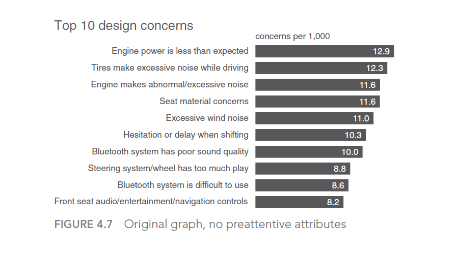

Basic plot

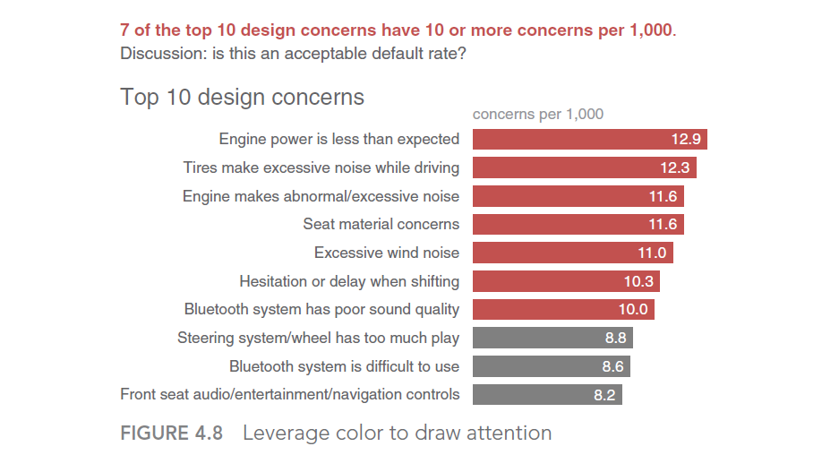

Better plot with colors guiding the eyes

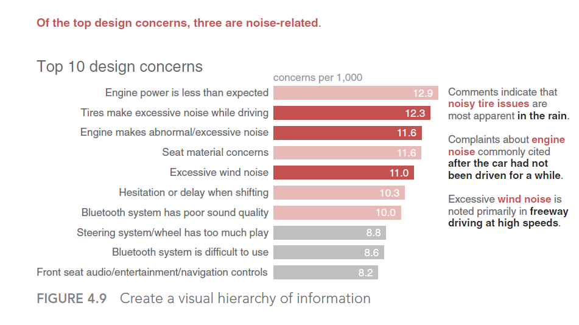

Informative with visual hierarchy and narrative

Here’s an example using the Rentals Data, where we want to map the properties and guide the audience to particular information.

Again, the original map.

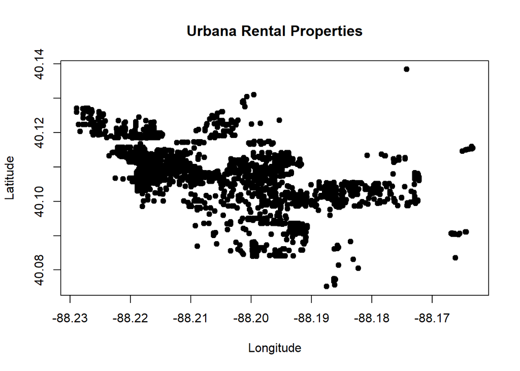

```r
plot(RentalsData2$Longitude,
     RentalsData2$Latitude,
     main="Urbana Rental Properties",
     pch=19,
     xlab="Longitude",
     ylab="Latitude")
```

The de-cluttered map.

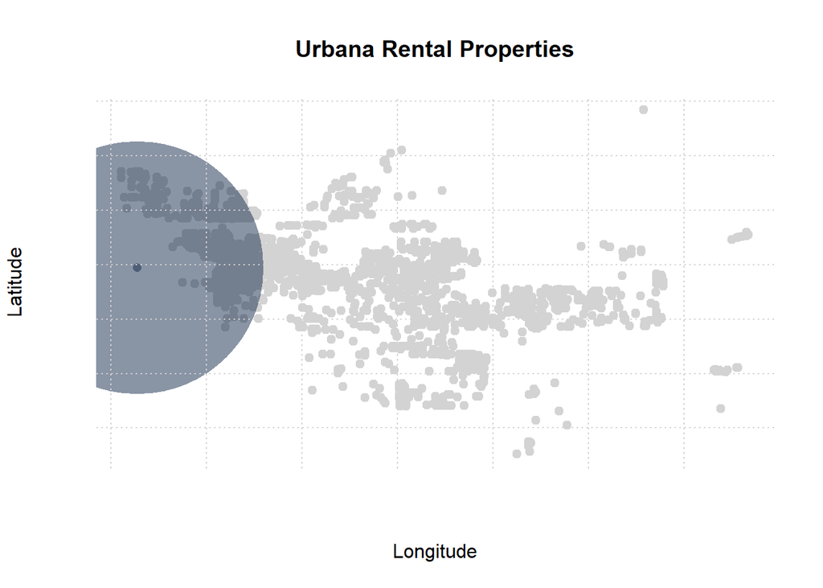

```r
plot(RentalsData2$Longitude,
     RentalsData2$Latitude,
     main="Urbana Rental Properties",
     pch=19,
     col="lightgray",
     xlab="Longitude",
     ylab="Latitude",
     frame.plot = FALSE,
     axes=FALSE)
points(-88.227244,
       40.109399,
       pch=19,
       col=rgb(19/255,41/255,75/255,alpha=0.5),
       lwd=200
       )
grid()
```

Next, we use some additional data wrangling.

```r
owners_addresses <- read_csv("https://uofi.box.com/shared/static/7m2hlut865herv9zzgzvyl4ort0j7rhr.csv")
RentalsData3 <- RentalsData2 %>%
  mutate(grade_n = ifelse(Grade=="Class N", 1, Grade),
         grade_f = ifelse(Grade=="Class F", 2, grade_n),
         grade_d = ifelse(Grade=="Class D", 3, grade_f),
         grade_c = ifelse(Grade=="Class C", 4, grade_d),
         grade_b = ifelse(Grade=="Class B", 5, grade_c),
         grade_numeric = as.numeric(ifelse(Grade=="Class A", 6, grade_b)),
         grade_prop = grade_numeric/6)

a_ids <- which(RentalsData3$Grade=="Class A")

RentalsData4 <- bind_cols(RentalsData3, owners_addresses) %>%
  rename(OwnerAddress=name)


city3 <- str_split(RentalsData4$OwnerAddress, "\\n", simplify=TRUE)[,3]
city4 <- str_split(RentalsData4$OwnerAddress, "\\n", simplify=TRUE)[,4]

urbana_n<- sum(str_count(city3,"URBANA")+str_count(city4,"URBANA"))
```

Then comes the map employing visual hierarchy.

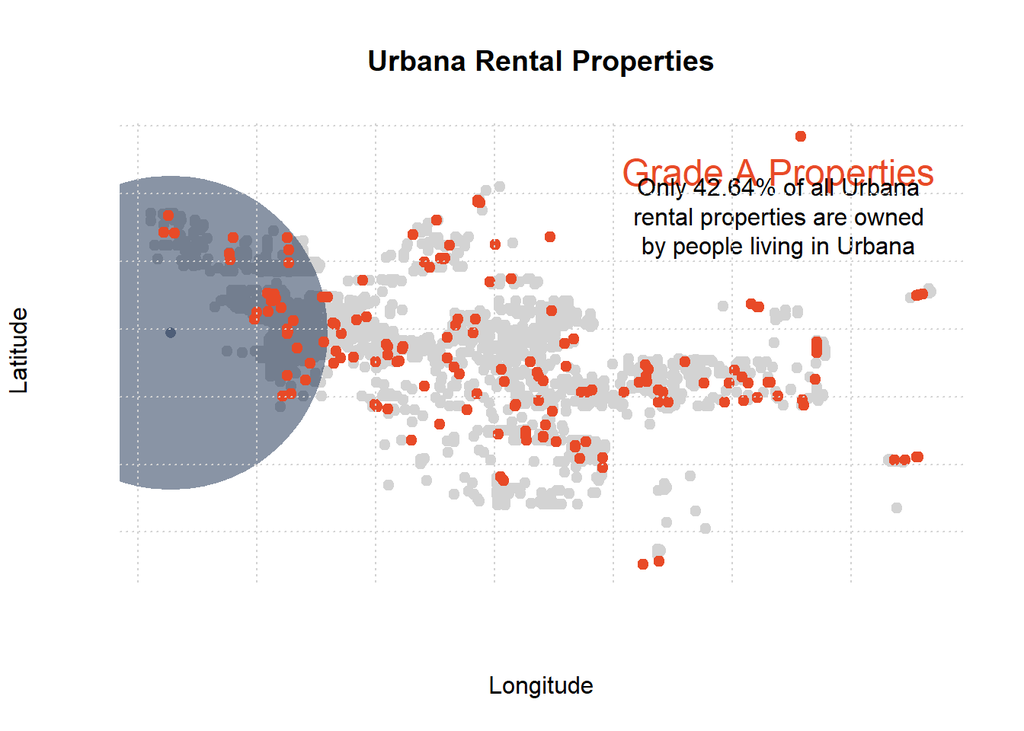

```r
plot(RentalsData4$Longitude,
     RentalsData4$Latitude,
     pch=19,
     col="lightgray",
     xlab="Longitude",
     ylab="Latitude",
     frame.plot = FALSE,
     axes=FALSE)
title(main="Urbana Rental Properties")
points(-88.227244,
       40.109399,
       pch=19,
       col=rgb(19/255,41/255,75/255,alpha=0.5), #blue radius
       lwd=200
       )
points(RentalsData4$Longitude[a_ids],
       RentalsData4$Latitude[a_ids],
       pch=19,
       col=rgb(232/255,74/255,39/255)) #orange dots
text(median(range(RentalsData4$Longitude))+0.02,
     median(range(RentalsData4$Latitude))+0.026,
     labels="Grade A Properties",
     col=rgb(232/255,74/255,39/255),
     cex=1.5)
text(median(range(RentalsData4$Longitude))+0.02,
     median(range(RentalsData4$Latitude))+0.02,
     labels=paste0("Only " ,round(100*urbana_n/nrow(RentalsData4),2), "% of all Urbana\n rental properties are owned \nby people living in Urbana"))
grid()
```